# Cleaning data from SSB API

Andreas Olden and Erling Risa

January 23, 2019

# Loading the data

```r
df_10594 <- readRDS(here("data/raw", "df_10594.rds"))
df_07459 <- readRDS(here("data/raw", "df_07459.rds"))
df_06726 <- readRDS(here("data/raw", "df_06726.rds"))
df_europe_brent_spot <- readRDS(here("data/raw", "df_europe_brent_spot.rds"))
```

# Looking, diagnozing and cleaning data

### 10594 unemployment

Let us start out by taking a look at the data frame, missing values and the regions

```r
skim(df_10594) #Show nice summary stats
```

```
Skim summary statistics
 n obs: 3648
 n variables: 5

-- Variable type:factor --------------------------------------------------------
 variable missing complete    n n_unique                             top_counts ordered
 contents       0     3648 3648        1                       Une: 3648, NA: 0   FALSE
    month       0     3648 3648      304     199: 12, 199: 12, 199: 12, 199: 12   FALSE
   region       0     3648 3648        4 Osl: 912, Sta: 912, Ber: 912, Tro: 912   FALSE
      sex       0     3648 3648        3 Bot: 1216, Mal: 1216, Fem: 1216, NA: 0   FALSE

-- Variable type:integer -------------------------------------------------------
 variable missing complete    n    mean      sd  p0  p25  p50  p75  p100     hist
    value       3     3645 3648 3427.85 3000.92 290 1366 2390 4440 16106 ▇▅▂▁▁▁▁▁
```

```r
df_10594[is.na(df_10594$value),] #To locate and show the missing values
```

|  | region | sex | contents | month | value |
| --- | --- | --- | --- | --- | --- |
| 3040 | Trondheim (-2017) | Both sexes | Unemployed persons registered at the Employment Offices | 2018M11 | NA |
| 3344 | Trondheim (-2017) | Males | Unemployed persons registered at the Employment Offices | 2018M11 | NA |
| 3648 | Trondheim (-2017) | Females | Unemployed persons registered at the Employment Offices | 2018M11 | NA |

```r
unique(df_10594$region) #To show all the regions
```

```
[1] Oslo municipality Stavanger         Bergen            Trondheim (-2017)
Levels: Oslo municipality Stavanger Bergen Trondheim (-2017)
```

The data consists of five variables; region, sex, contents, month and value. All are unordered factors, except for value, which is integer. There are aslo 4 regions, Oslo muni, Stavanger, Bergen and Trondheim (-2017). There are also three missing values, all from Trondheim in 2018, despite the fact that the data states -2017. This is due to the previous issue of Trondheim being classified as 1601 and 5001 and presumably a mistake by SSB. By looking at the relevant table in the Statbank https://www.ssb.no/statbank/table/10594 we could replace them or merge the variables. However, since the housing price data only runs from 1992-2017 we will only use this time period, and not have to deal with it.

We also want to clean the data a bit. The goal is to merge all data frames into a single data frame, so we aim for long data sets with consistent names and values.

The contents variable provides a description of the value variable. The contents has the description (factor level) “Unemployed persons registered at the Employment Offices”. This is too long to work with and we will recode it as “reg_unemployed”. We also want to recode the factor variable month as a date format. Then we will recode the factor levels in region so that Oslo muni is simply Oslo and Trondheim (-2017) is only Trondheim. Then we also want the sex factor level “Both sexes” to be named population. Further we will recode the value variable as numeric rather than integer. Then we will filter the dataset so that only dates between 1992 and 2017 are included. Finally we save it in processed data. We go through most of these steps in all the SSB data.

```r
df_10594 <- df_10594 %>%
        mutate( contents = fct_recode(contents,
                                      reg_unemployed = "Unemployed persons registered at the Employment Offices"),
                date = lubridate::parse_date_time(month, "ym"),
                region = fct_recode(region,
                                    Oslo = "Oslo municipality",
                                    Trondheim = "Trondheim (-2017)"),
                sex = fct_recode(sex,
                                 Population = "Both sexes"),
                value = as.numeric(value)
                ) %>%
        select(-month) %>%
        filter(date >= as.Date("1992-01-01") & date < as.Date("2018-01-01"))

saveRDS(df_10594, file = here("data/processed", "df_unemployment.rds"))
```

Let’s take a new look at the data

```r
skim(df_10594)
```

```
Skim summary statistics
 n obs: 3348
 n variables: 5

-- Variable type:factor --------------------------------------------------------
 variable missing complete    n n_unique                             top_counts ordered
 contents       0     3348 3348        1                       reg: 3348, NA: 0   FALSE
   region       0     3348 3348        4 Osl: 837, Sta: 837, Ber: 837, Tro: 837   FALSE
      sex       0     3348 3348        3 Pop: 1116, Mal: 1116, Fem: 1116, NA: 0   FALSE

-- Variable type:numeric -------------------------------------------------------
 variable missing complete    n    mean      sd  p0    p25    p50    p75  p100     hist
    value       0     3348 3348 3384.16 3011.92 290 1346.5 2306.5 4382.5 16106 ▇▅▂▁▁▁▁▁

-- Variable type:POSIXct -------------------------------------------------------
 variable missing complete    n        min        max     median n_unique
     date       0     3348 3348 1992-01-01 2017-11-01 2003-08-01      279
```

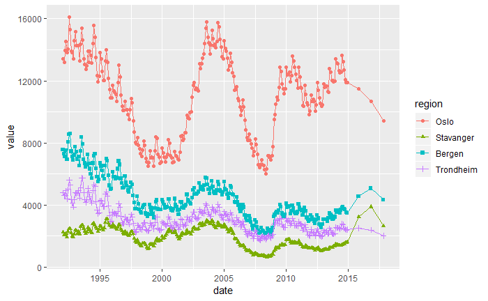

```r
ggplot(subset(df_10594, sex == "Population"), aes(x = date, y = value, colour = region)) + geom_point(aes(shape = region)) + geom_line()
```

### 07459 Population by region, age and gender

Let’s take a look

```r
skim(df_07459)
```

```
Skim summary statistics
 n obs: 27984
 n variables: 6

-- Variable type:factor --------------------------------------------------------
 variable missing complete     n n_unique                                 top_counts ordered
      age       0    27984 27984      106     0 y: 264, 1 y: 264, 2 y: 264, 3 y: 264   FALSE
 contents       0    27984 27984        1                          Per: 27984, NA: 0   FALSE
   region       0    27984 27984        4 Osl: 6996, Sta: 6996, Ber: 6996, Tro: 6996   FALSE
      sex       0    27984 27984        2              Mal: 13992, Fem: 13992, NA: 0   FALSE
     year       0    27984 27984       33     198: 848, 198: 848, 198: 848, 198: 848   FALSE

-- Variable type:integer -------------------------------------------------------
 variable missing complete     n    mean      sd p0 p25 p50  p75 p100     hist
    value       0    27984 27984 1222.16 1221.38  0 395 917 1590 8186 ▇▃▁▁▁▁▁▁
```

```r
unique(df_07459$region)
```

```
[1] Oslo municipality Stavanger         Bergen            Trondheim (-2017)
Levels: Oslo municipality Stavanger Bergen Trondheim (-2017)
```

This time we have six variables: age, contents, region, sex, year and value. There are no mising values, but there are a lot of zero values for the population, which can be correct (no 110 year olds in a given year), but it can also be missing, which in fact is the case for Trondheim in 2018. Luckily, we are not going to use 2018 so we do not have to worry about it.

We also see that we only have two sexes, males and females. We will transform the data to wide format to easily sum up the two to get the total population numbers. Then we will gather the data so that it is in the usual long format. We will then recode the factor level in contents from Persons to Inhabitants, then recode the region factor levels as previously, and recode the value variable as numeric. This time the observational level is year. We will recode it as a date, but the default option in R is to use 1st of January in this case. As it is a yearly average both the start and the end of the year seems like strange choices. Hence, we will add 183 days to the date to get roughly in the middle of the year. Then we will filter the data and save it in processed data.

```r
#Create for total population using spread
df_07459 <- df_07459 %>%
        spread( key = sex, value = value) %>%
        mutate( Population = Males + Females) %>%
        gather( key = "sex", value = "value", Males, Females, Population) %>%
        mutate( contents = fct_recode(contents,
                                      Inhabitants = "Persons"),
                region = fct_recode(region,
                                    Oslo = "Oslo municipality",
                                    Trondheim = "Trondheim (-2017)"),
                value = as.numeric(value),
                sex = as.factor(sex),
                date = (lubridate::parse_date_time(year, "y") + lubridate::days(183))
                ) %>%
        select(-year) %>%
        filter(date >= as.Date("1992-01-01") & date < as.Date("2018-01-01"))

saveRDS(df_07459, file = here("data/processed", "df_population.rds"))
```

Let’s take a look:

```r
skim(df_07459)
```

```
Skim summary statistics
 n obs: 33072
 n variables: 6

-- Variable type:factor --------------------------------------------------------
 variable missing complete     n n_unique                                 top_counts ordered
      age       0    33072 33072      106     0 y: 312, 1 y: 312, 2 y: 312, 3 y: 312   FALSE
 contents       0    33072 33072        1                          Inh: 33072, NA: 0   FALSE
   region       0    33072 33072        4 Osl: 8268, Sta: 8268, Ber: 8268, Tro: 8268   FALSE
      sex       0    33072 33072        3  Fem: 11024, Mal: 11024, Pop: 11024, NA: 0   FALSE

-- Variable type:numeric -------------------------------------------------------
 variable missing complete     n    mean      sd p0 p25  p50  p75  p100     hist
    value       0    33072 33072 1676.64 1857.45  0 522 1103 2067 15372 ▇▂▁▁▁▁▁▁

-- Variable type:POSIXct -------------------------------------------------------
 variable missing complete     n        min        max     median n_unique
     date       0    33072 33072 1992-07-02 2017-07-03 2005-01-01       26
```

### 06726 housing prices by number and total value by region

```r
skim(df_06726) #Show nice summary stats
```

```
Skim summary statistics
 n obs: 260
 n variables: 4

-- Variable type:factor --------------------------------------------------------
 variable missing complete   n n_unique                         top_counts ordered
 contents       0      260 260        2          Tra: 130, Tot: 130, NA: 0   FALSE
   region       0      260 260        5 The: 52, Osl: 52, Sta: 52, Ber: 52   FALSE
     year       0      260 260       26 199: 10, 199: 10, 199: 10, 199: 10   FALSE

-- Variable type:integer -------------------------------------------------------
 variable missing complete   n       mean          sd   p0     p25    p50         p75      p100     hist
    value       0      260 260 18995312.9 51542040.72 1008 4012.75 357180 10544921.25 315634243 ▇▁▁▁▁▁▁▁
```

```r
unique(df_06726$region) #To show all the regions
```

```
[1] The whole country Oslo municipality Stavanger         Bergen            Trondheim (-2017)
Levels: The whole country Oslo municipality Stavanger Bergen Trondheim (-2017)
```

```r
unique(df_06726$contents) #To show all info provided
```

```
[1] Transfers (number)               Total purchase prise (1 000 NOK)
Levels: Transfers (number) Total purchase prise (1 000 NOK)
```

This also looks a lot like the previous data sets. There are 4 variables: Contents, region, year and value. There are no missing values.

The contents variable has two pieces, transfers and total value. We want the average value as well and will spread the data set so that it becomes wide, then calculate the average value before we gather it back as a long data set. Along the way we will rename the variables when in the long format so that there are no spaces. Then we will recode the factor levels for region, and change the year to date format as previously. Finally, let’s save and have a look.

```r
df_06726 <- df_06726 %>%
        spread( key = contents, value = value) %>%
        rename( home_transfers = "Transfers (number)", trans_val_in_1000 = "Total purchase prise (1 000 NOK)") %>%
        mutate( ave_home_price = (trans_val_in_1000 / home_transfers)*1000 ) %>%
        gather( key = "contents", value = "value", home_transfers, trans_val_in_1000, ave_home_price, factor_key = TRUE ) %>%
        mutate(
                region = fct_recode(region,
                                    Norway = "The whole country",
                                    Oslo = "Oslo municipality",
                                    Trondheim = "Trondheim (-2017)"),
                date = (lubridate::parse_date_time(year, "y") + lubridate::days(183))
        ) %>%
        select(-year) %>%
        filter(date >= as.Date("1992-01-01") & date < as.Date("2018-01-01"))

saveRDS(df_06726, file = here("data/processed", "df_home_values.rds"))
```

Let’s take a look:

```r
skim(df_06726)
```

```
Skim summary statistics
 n obs: 390
 n variables: 4

-- Variable type:factor --------------------------------------------------------
 variable missing complete   n n_unique                          top_counts ordered
 contents       0      390 390        3 hom: 130, tra: 130, ave: 130, NA: 0   FALSE
   region       0      390 390        5  Nor: 78, Osl: 78, Sta: 78, Ber: 78   FALSE

-- Variable type:numeric -------------------------------------------------------
 variable missing complete   n        mean          sd   p0   p25        p50        p75      p100     hist
    value       0      390 390 13426828.04 42796259.87 1008 10501 1688487.75 4854728.13 315634243 ▇▁▁▁▁▁▁▁

-- Variable type:POSIXct -------------------------------------------------------
 variable missing complete   n        min        max     median n_unique
     date       0      390 390 1992-07-02 2017-07-03 2005-01-01       26
```

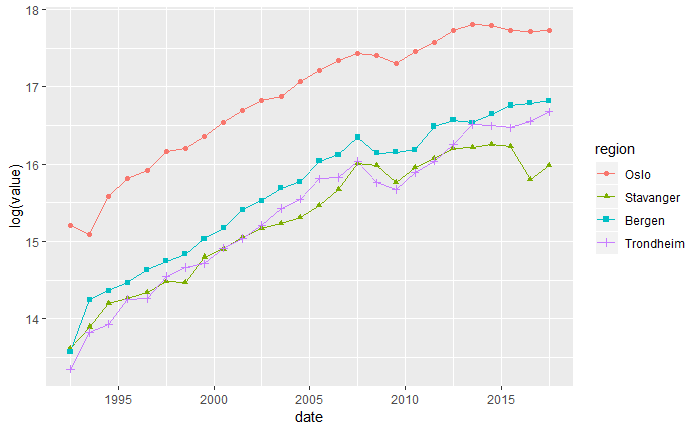

```r
#The total transfer value for the four cities in log-scale
ggplot (subset(df_06726, contents == "trans_val_in_1000"  & region != "Norway"), aes(x = date, y = log(value), colour = region )) + geom_line() + geom_point(aes(shape=region))
```

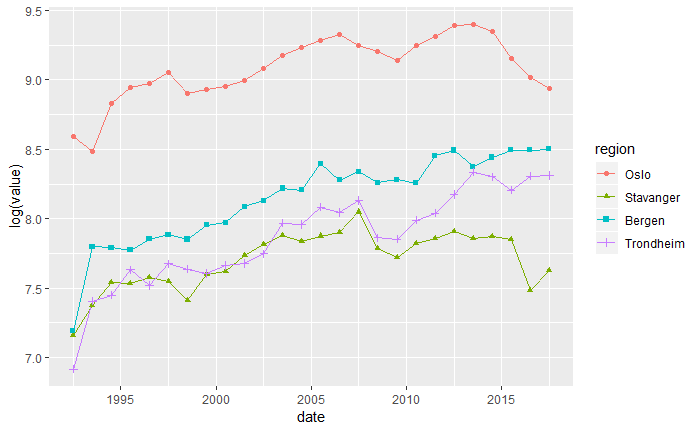

```r
#The number of home transfers in the four cities in log-scale
ggplot (subset(df_06726, contents == "home_transfers" & region != "Norway"), aes(x = date, y = log(value), colour = region )) + geom_line() + geom_point(aes(shape=region))
```

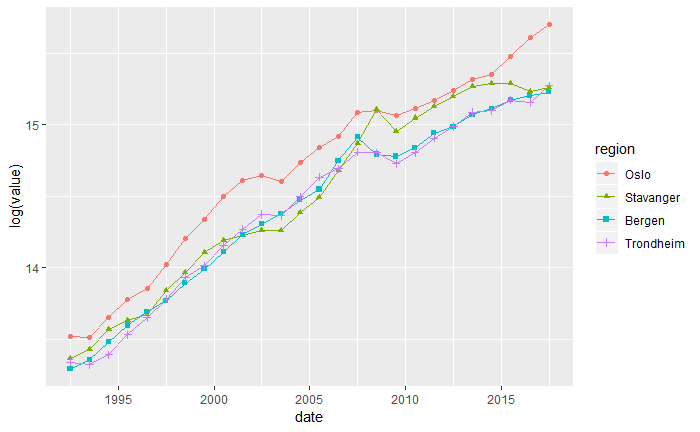

```r
#The average home values in the four cities in log-scale
ggplot (subset(df_06726, contents == "ave_home_price"  & region != "Norway"), aes(x = date, y = log(value), colour = region )) + geom_line() + geom_point(aes(shape=region))
```

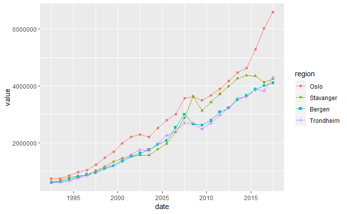

```r
#The average home value for the four cities in levels
ggplot (subset(df_06726, contents == "ave_home_price"  & region != "Norway"), aes(x = date, y = value, colour = region )) + geom_line() + geom_point(aes(shape=region))
```

### The Europe Brent Spot Price

```r
skim(df_europe_brent_spot)
```

```
Skim summary statistics
 n obs: 381
 n variables: 2

-- Variable type:numeric -------------------------------------------------------
 variable missing complete   n mean    sd   p0   p25  p50   p75   p100     hist
    price       0      381 381   46 33.01 9.82 18.67 30.2 67.49 132.72 ▇▃▂▂▂▁▂▁

-- Variable type:POSIXct -------------------------------------------------------
 variable missing complete   n        min        max     median n_unique
     date       0      381 381 1987-05-15 2019-01-15 2003-03-15      381
```

This data frame does not having any missing values and two variables, price and date. We want to rename the price variable as value, and create a contents variable called oil_prices. Finally we will add region (Norway), even though that is not technically correct. Finally we will filter the data and save it.

```r
df_europe_brent_spot <- df_europe_brent_spot %>%
        rename( value = price) %>%
        mutate( contents = as.factor("oil_price"),
                region = as.factor("Norway") ) %>%
        filter(date >= as.Date("1992-01-01") & date < as.Date("2018-01-01"))
saveRDS(df_europe_brent_spot, file = here("data/processed", "df_brent_oil_price.rds"))
```

And we are good to go. Let’s take a look:

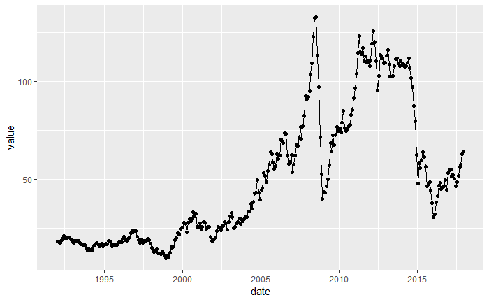

```r
#Oil prices in levels
ggplot (df_europe_brent_spot, aes(x = date, y = value)) + geom_line() + geom_point()
```

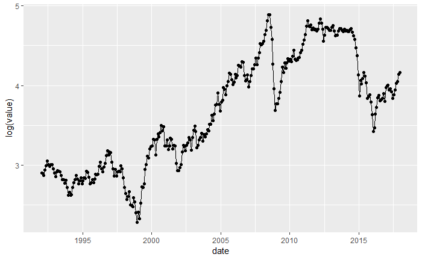

```r
#Oil prices in log(value)
ggplot (df_europe_brent_spot, aes(x = date, y = log(value))) + geom_line() + geom_point()
```

# Putting it all in a single data frame

Let us first read in the saved data frames in case we ever want to work only on the final data frame.

```r
df_unemployment <- readRDS(here("data/processed", "df_unemployment.rds"))
df_population <- readRDS(here("data/processed", "df_population.rds"))
df_home_values <- readRDS(here("data/processed", "df_home_values.rds"))
df_brent_oil_price <- readRDS(here("data/processed", "df_brent_oil_price.rds"))
```

Then we use the full_join from Dplyr to pipe the datasets together and save it.

```r
df_joined_data <- full_join(df_unemployment, df_population) %>%
        full_join(., df_home_values) %>%
        full_join(., df_brent_oil_price ) %>%
        mutate(region = as.factor(region),
               sex = as.factor(sex),
               contents = as.factor(contents))
```

```
Column `sex` joining factors with different levels, coercing to character vectorColumn `contents` joining factors with different levels, coercing to character vectorJoining, by = c("region", "contents", "value", "date")
Column `region` joining factors with different levels, coercing to character vectorColumn `contents` joining character vector and factor, coercing into character vectorJoining, by = c("region", "contents", "value", "date")
Column `region` joining character vector and factor, coercing into character vectorColumn `contents` joining character vector and factor, coercing into character vector
```

```r
saveRDS(df_joined_data, file = here("data/processed", "df_joined_data.rds"))
```

And take a look:

```r
skim(df_joined_data)
```

```
Skim summary statistics
 n obs: 37122
 n variables: 6

-- Variable type:factor --------------------------------------------------------
 variable missing complete     n n_unique                                  top_counts ordered
      age    4050    33072 37122      106      NA: 4050, 0 y: 312, 1 y: 312, 2 y: 312   FALSE
 contents       0    37122 37122        6   Inh: 33072, reg: 3348, oil: 312, ave: 130   FALSE
   region       0    37122 37122        5  Ber: 9183, Osl: 9183, Sta: 9183, Tro: 9183   FALSE
      sex     702    36420 37122        3 Fem: 12140, Mal: 12140, Pop: 12140, NA: 702   FALSE

-- Variable type:numeric -------------------------------------------------------
 variable missing complete     n      mean         sd p0 p25  p50     p75      p100     hist
    value       0    37122 37122 142860.26 4589835.73  0 582 1225 2336.75 315634243 ▇▁▁▁▁▁▁▁

-- Variable type:POSIXct -------------------------------------------------------
 variable missing complete     n        min        max     median n_unique
     date       0    37122 37122 1992-01-01 2017-12-15 2004-07-02      617
```

```r
unique(df_joined_data$region)
```

```
[1] Oslo      Stavanger Bergen    Trondheim Norway
Levels: Bergen Norway Oslo Stavanger Trondheim
```

```r
unique(df_joined_data$sex)
```

```
[1] Population Males      Females    <NA>
Levels: Females Males Population
```

```r
unique(df_joined_data$contents)
```

```
[1] reg_unemployed    Inhabitants       home_transfers    trans_val_in_1000 ave_home_price    oil_price
Levels: ave_home_price home_transfers Inhabitants oil_price reg_unemployed trans_val_in_1000
```

And that’s it. We can now create our app. Note that there are now many missing values, which is completely natural. Oil prices, house prices and unemployment numbers do not have an age, and the same argument goes for sex. Happily, we see that contents, region and value, which should not have any missing values, do not have any missing values.